# placentaProfile

Melanie Smith

24 September, 2017

# Import Counts and Sample Data

This step imports the raw counts data and samples metadata and reports some summary information.

```r
library(tidyverse)
library(magrittr)
library(pander)

# import miRNA counts table from VM
countsPlacenta <- read.table(("~/placentaBcbio/placenta/final/2017-05-23_placenta/counts_mirna.tsv"),
                             sep="\t",
                             header=T,
                             row.names="mirna")

# remove the "_R1" and replace "Q" with "PAC" from the column names (eg Q006_S1_R1 becomes PAC006 to match the 'samples' data.frame) in the 'counts' data.frame
names(countsPlacenta) = sub("_R1","",names(countsPlacenta))
names(countsPlacenta) = sub("Q","PAC",names(countsPlacenta))
names(countsPlacenta) = sub("_S.*","",names(countsPlacenta))
# correct sample name mislabeled by QIAGEN
names(countsPlacenta) = sub("PAC033","PAC038",names(countsPlacenta))
# Reorder data.frame by columns
countsPlacenta <- countsPlacenta[,order(colnames(countsPlacenta),decreasing=FALSE)]

# import the samples data from VM
samples <- readr::read_delim("~/placenta_miRNA.tsv", delim = "\t") %>%
  dplyr::select(-starts_with("X"))

samples <- samples[,c(1, 12:16)] %>%
  as.data.frame() %>%
  magrittr::set_colnames(c("samplename", "maternalAge", "gestation", "BMI", "smoker", "ethnicity")) %>%
  mutate(samplename = paste0("PAC",stringr::str_pad(samplename, width = 3, pad = "0")))

# Remove the "+" from column 4 "gestation" nb: escape special character using \\
samples$gestation <- gsub("\\+", "", samples$gestation)

# reassign object classes
samples$gestation <- as.integer(samples$gestation)

# add new column named "group" into samples data.frame
samples$group <- rep(NA, 48)

# add new group 'Trimester 1 or 2' factor to each row based on gestation
# Trimester 1 = 6-13 wks, Trimester 2 = 14-26 wks
samples$group <- ifelse(samples$gestation<=13, "Trimester_1",
                        ifelse(samples$gestation>=14, "Trimester_2", NA))

# group as factor
samples$group <- as.factor(samples$group)

samples <- as.data.frame(samples)

# Add fetal sex to samples df
fetalSex <- read.csv("~/Bcbioplasma/fetalSex.csv", header = TRUE) %>%
  dplyr::select(-matches("gestation")) %>%
  mutate(samplename = paste0("PAC", stringr::str_pad(samplename, width = 3, pad = "0")))

fetalSex$Sex <- ifelse(fetalSex$fetalSex == "XX" , "Female",
                       ifelse(fetalSex$fetalSex == "XY", "Male", NA))

samples <- left_join(samples, fetalSex, by = "samplename")

# summary tables
pandoc.table(samples,
             caption = "Meta Data for all placenta samples",
             split.table=Inf)
```

```
##
## ---------------------------------------------------------------------------------------------------
##  samplename   maternalAge   gestation   BMI   smoker     ethnicity       group     fetalSex   Sex
## ------------ ------------- ----------- ----- -------- --------------- ----------- ---------- ------
##    PAC006         32            9       33      N        Caucasian    Trimester_1     XX     Female
##
##    PAC007         28           10      18.8     N        Caucasian    Trimester_1     XY      Male
##
##    PAC008         26            9       25      N        Caucasian    Trimester_1     XX     Female
##
##    PAC009         30            8       23      Y        Caucasian    Trimester_1     XX     Female
##
##    PAC010         31            8       19      N        Caucasian    Trimester_1     XX     Female
##
##    PAC011         29           11       27      N        Caucasian    Trimester_1     XY      Male
##
##    PAC012         29            7      18.3     N         Indian      Trimester_1     XX     Female
##
##    PAC013         28           10      19.2     N          Asian      Trimester_1     XX     Female
##
##    PAC014         21            9      20.1     N        Caucasian    Trimester_1     XY      Male
##
##    PAC015         35           11       21      Y        Caucasian    Trimester_1     XX     Female
##
##    PAC016         27            9      23.9     Y       Aboriginal    Trimester_1     XY      Male
##
##    PAC017         27           14      25.1     N        Caucasian    Trimester_2     XX     Female
##
##    PAC024         31            6      24.7     Y        Caucasian    Trimester_1     XX     Female
##
##    PAC025         25            7       20      N        Caucasian    Trimester_1     XY      Male
##
##    PAC026         18           16       21      N        Caucasian    Trimester_2     XY      Male
##
##    PAC027         29           16      25.5     N         Indian      Trimester_2     XX     Female
##
##    PAC030         32           13      25.8     Y        Caucasian    Trimester_1     XY      Male
##
##    PAC031         20           16      17.9     N        Caucasian    Trimester_2     XY      Male
##
```

[output cut: 47 more lines]

```
##
##    PAC058         17           16       22      Y       Aboriginal    Trimester_2     XX     Female
##
##    PAC059         25           10       26      Y          Asian      Trimester_1     XX     Female
##
##    PAC060         31            9       22      Y        Caucasian    Trimester_1     XY      Male
##
##    PAC062         29           10       27      Y        Caucasian    Trimester_1     XY      Male
##
##    PAC063         32            9      21.3     N        Caucasian    Trimester_1     XY      Male
##
##    PAC064         33            7       27      N        Caucasian    Trimester_1     XX     Female
## ---------------------------------------------------------------------------------------------------
##
## Table: Meta Data for all placenta samples
```

```r
summary(samples$group)
```

```
## Trimester_1 Trimester_2
##          41           7
```

```r
summary(samples$fetalSex)
```

```
## XX XY
## 25 23
```

```r
lapply(samples[, c(2:8)], function(x) {
    if (is.numeric(x)) return(summary(x))
    if (is.integer(x)) return(summary(x))
    if (is.factor(x)) return(table(x))
    if (is.character(x)) return(table(x))
})
```

```
## $maternalAge
##    Min. 1st Qu.  Median    Mean 3rd Qu.    Max.
##   17.00   22.00   27.00   26.46   30.00   43.00
##
## $gestation
##    Min. 1st Qu.  Median    Mean 3rd Qu.    Max.
##   6.000   7.000   9.000   9.625  11.000  16.000
##
## $BMI
##    Min. 1st Qu.  Median    Mean 3rd Qu.    Max.
##   17.90   20.00   23.05   23.74   26.00   35.00
##
## $smoker
## x
##  N  Y
## 33 15
##
## $ethnicity
## x
##      Aboriginal         African           Asian       Caucasian
##               3               1               3              36
##          Indian Solomon Islands
##               4               1
##
## $group
## x
## Trimester_1 Trimester_2
##          41           7
##
## $fetalSex
## x
## XX XY
## 25 23
```

### Plot to visualise the pre filtered, unique miRNA population between samples in Placenta

From the raw counts we can see that there is not a lot of difference in the number of unique miRNAs identified between samples, however the actual population of miRNAs between samples does differ.

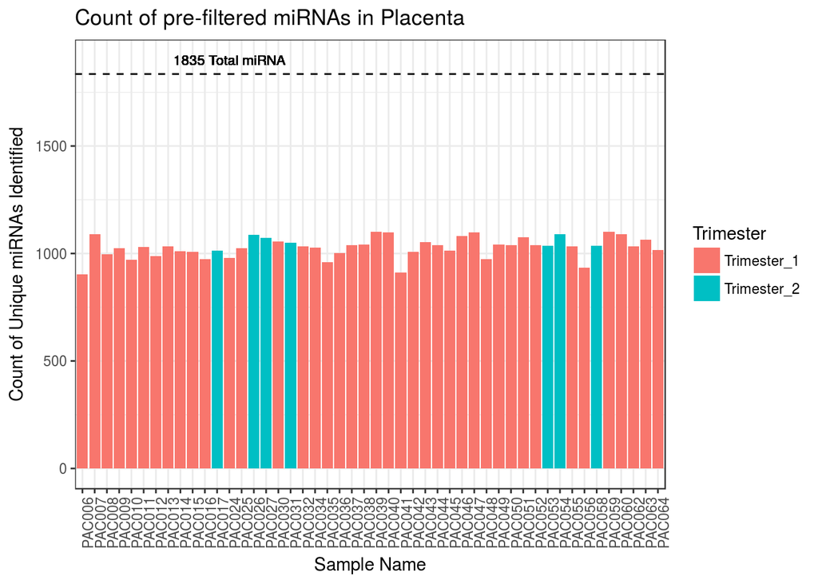

```r
library(tidyverse)
library(magrittr)
library(dplyr)

# set ggplot2 theme
theme_set(theme_bw())

# count the number of 'non-zero' (ie expressed) miRNAs for each sample before filtering
nonzero <- function(x) sum(x != 0)

rawNonZero <- plyr::numcolwise(nonzero)(countsPlacenta) %>%
  t() %>%
  as.data.frame() %>%
  tibble::rownames_to_column() %>%
  set_colnames(c("samplename", "rawmiRNA")) %>%
  as.data.frame()

# produce plot of # unique miRNA per sample
#png("rawmiRNAPlacenta.png")
ggplot(data=rawNonZero, aes(x=samplename, y=rawmiRNA, fill = samples$group)) +
  geom_bar(stat="identity") +
  theme(axis.text.x = element_text(angle = 90, hjust = 1)) +
  labs(x = "Sample Name", y = "Count of Unique miRNAs Identified", title = "Count of pre-filtered miRNAs in Placenta") +
  geom_hline(yintercept=1835,linetype="dashed") +
  geom_text(aes(13, 1900, label = "1835 Total miRNA"), size = 3, colour = "black") +
  scale_fill_discrete(name = "Trimester")
```

```r
#dev.off()
```

We start with a total of 1835 unique miRNAs - of which no single sample has more than 1102 individual miRNAs.

# Filter sequencing noise

Here any individual observation with less than 5 counts is considered to be sequencing noise and is reduced to zero and removed by filtering.  
* Counts less than 5 reduced to 0 * Logic check and record how many miRs will be filtered * Filter to remove miRs with zero counts in all samples

```r
# exclude any individual count less than 5
countsPlacenta[countsPlacenta < 5] <- 0

# check to establish if any miRNA have no expression across all samples
table(rowSums(countsPlacenta==0) == 48)
```

```
##
## FALSE  TRUE
##  1256   579
```

```r
# remove miRNAs with zero counts in all samples
countsPlacenta <- countsPlacenta[ rowSums(countsPlacenta)!=0, ]
```

After filtering out the sequencing noise (sequence counts with low confidence) we are left with 1256 unique miRNAs (579 are filtered as counts noise).

# Establish DGEList object

The counts and samples data can now be combined into a single list object for use in differential expression analysis downstream.

```r
# load required Libraries
library(edgeR)
library(tidyverse)

# new df of miRNA names for DGEList object
genes <- as.character(rownames(countsPlacenta)) %>%
  as.data.frame() %>%
  set_colnames("SYMBOL")

# new DGEList object for differential expression analysis
DGEList_placenta <- DGEList(counts=countsPlacenta, samples=samples, genes = genes)

# saveRDS(DGEList_placenta, "rawDGEList_placenta.rds")
```

# TMM normalisation of libraries

Before differential expression analysis the sample libraries need to be normalised to account for differences in initial library size.  
Normalising the libraries allows for the direct comparison between samples.  
Here the Trimmed Mean of M Values method is used.  
Prior to normalisation the placenta libraries are within a similar range, however the mean of counts is small and centered around 0-1 CPM (log2)

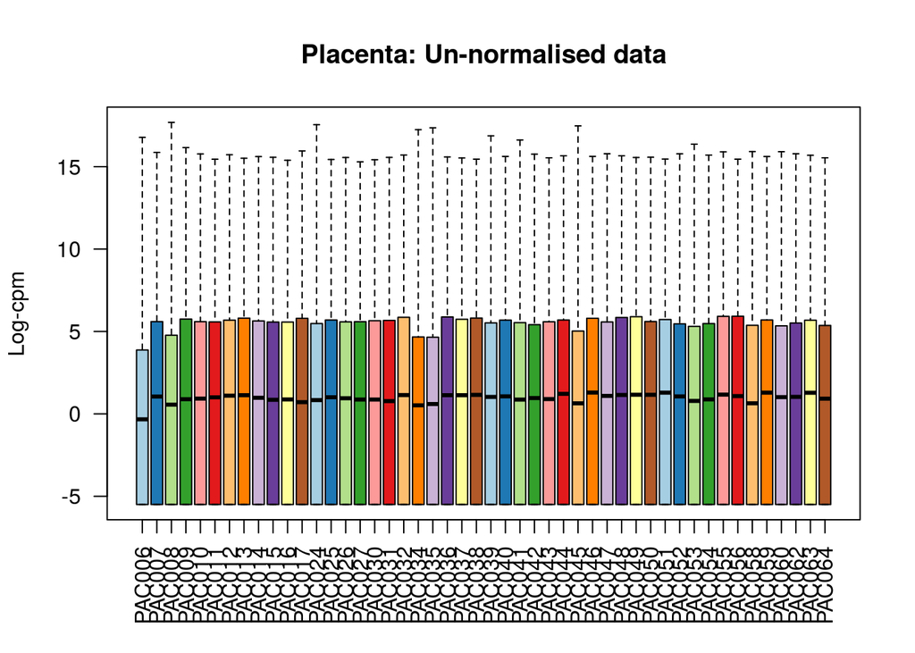

```r
library(RColorBrewer)

# Distribution of un-normalised counts
nsamples <- ncol(DGEList_placenta)
col <- brewer.pal(nsamples, "Paired")

lcpm <- cpm(DGEList_placenta, log=TRUE)
boxplot(lcpm, las=2, col=col, main="")
title(main="Placenta: Un-normalised data",ylab="Log-cpm")
```

```r
# calculate normalisation factors and apply to the DGEList object
DGEList_placenta <- calcNormFactors(DGEList_placenta, method="TMM")
```

# Filter biological noise and plot

```r
library(plyr)
```

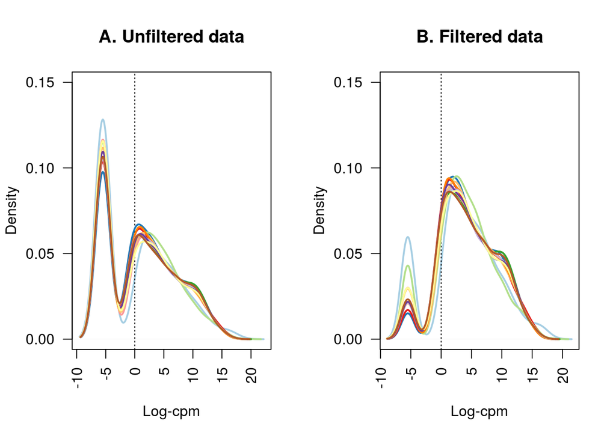

```r
library(tidyverse)
library(edgeR)

# set ggplot theme
theme_set(theme_bw())

# new df of unfiltered cpm for the reduced DGEList
rawCpm_placenta <- cpm(DGEList_placenta)

# new df of unfiltered log 2 cpm for the reduced DGEList
rawlcpm_placenta <- cpm(DGEList_placenta, log = TRUE)

# remove lowly expressed genes
keep.exprs <- rowSums(rawCpm_placenta > 1) >= 7
DGEList_placenta <- DGEList_placenta[keep.exprs,, keep.lib.sizes=FALSE]

## The density of log-CPM values for pre-filtered data (A) and post-filtered data (B) are shown for each sample.
## Dotted vertical lines mark the log-CPM of zero threshold (equivalent to a CPM value of 1) used in the filtering step.

nsamples <- ncol(DGEList_placenta)
col <- brewer.pal(nsamples, "Paired")
par(mfrow=c(1,2))
plot(density(rawlcpm_placenta[,1]), col=col[1], lwd=2, ylim=c(0,0.15), las=2,
  main="", xlab="")
title(main="A. Unfiltered data", xlab="Log-cpm")
abline(v=0, lty=3)
for (i in 2:nsamples){
  den <- density(rawlcpm_placenta[,i])
  lines(den$x, den$y, col=col[i], lwd=2)
}
#legend("topright", legend=samples$samplename, text.col=col, bty="n")

lcpm <- cpm(DGEList_placenta, log=TRUE)
plot(density(lcpm[,1]), col=col[1], lwd=2, ylim=c(0,0.15), las=2,
  main="", xlab="")
title(main="B. Filtered data", xlab="Log-cpm")
abline(v=0, lty=3)
for (i in 2:nsamples){
  den <- density(lcpm[,i])
lines(den$x, den$y, col=col[i], lwd=2)
}
```

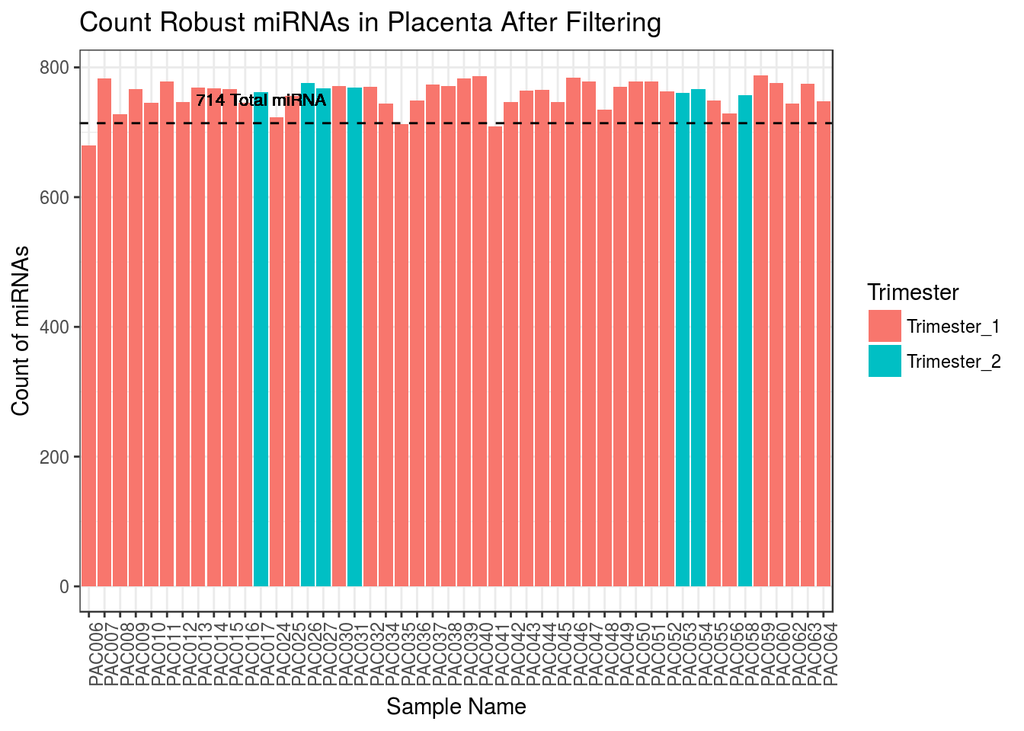

```r
#legend("topright", legend=samples$samplename, text.col=col, bty="n")

par(mfrow=c(1,1))

# Plot filtered library sizes against total miRNA
# count the number of 'non-zero' (ie expressed) miRNAs for each sample after filtering
filteredNonZero <- (DGEList_placenta[[1]]) %>%
  as.data.frame()

filteredNonZero <-  t(numcolwise(nonzero)(filteredNonZero)) %>%
  as.data.frame() %>%
  tibble::rownames_to_column()

#png("robustmiRNAPlacenta.png")
ggplot(data=filteredNonZero, aes(x=rowname, y=V1, fill=samples$group)) +
  geom_bar(stat="identity") +
  theme(axis.text.x = element_text(angle = 90, hjust = 1)) +
  labs(x = "Sample Name", y = "Count of miRNAs", title = "Count Robust miRNAs in Placenta After Filtering") +
  geom_hline(yintercept=714,linetype="dashed") +
  geom_text(aes(12, 750, label = "714 Total miRNA"), size = 3, colour = "black") +
  scale_fill_discrete(name = "Trimester")
```

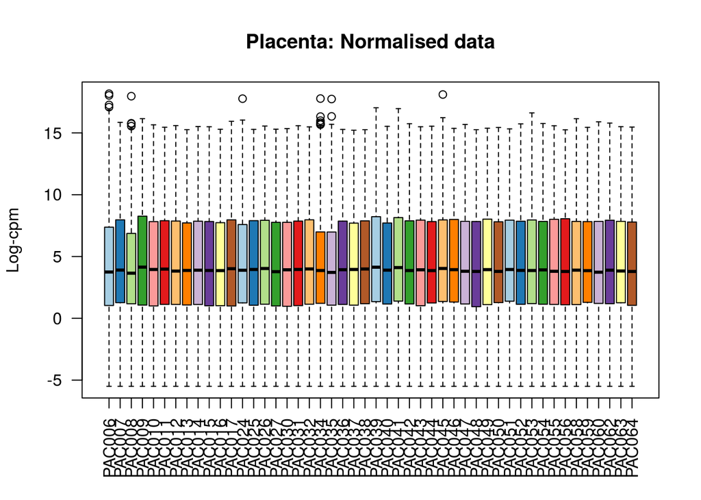

```r
#dev.off()

# Distribution of normalised and filtered counts data
lcpm <- cpm(DGEList_placenta, log=TRUE)
boxplot(lcpm, las=2, col=col, main="")
title(main="Placenta: Normalised data",ylab="Log-cpm")
```

### table - top 20 miRNA in placenta by mean expression value (CPM)

```r
# create expression DF for normalised placenta counts
expressionPlacenta <- cpm(DGEList_placenta$counts) %>%
  as.data.frame()

# subset the top 20 highly expressed miRs by the sum of expression over all samples.
expressionPlacentaTop20 <- expressionPlacenta[order(rowMeans(expressionPlacenta), decreasing = TRUE), ] %>%
  as.data.frame() %>%
  tibble::rownames_to_column("miRNAs") %>%
  as.data.frame() %>%
  dplyr::slice(., 1:20) %>%
  mutate(meanCPM = rowMeans(.[grep("^PAC", names(.))])) %>%
  select(., -matches("PAC"))
expressionPlacentaTop20$Tissue <- "Placenta"
# expressionPlacentaTop20$TissueSpecificity <- "unknown"
# expressionPlacentaTop20$PregnancySpecificity <- "unknown"

pandoc.table(expressionPlacentaTop20)
```

```
##
## ----------------------------------
##     miRNAs       meanCPM   Tissue
## --------------- --------- --------
##  hsa-miR-21-5p    58284   Placenta
##
## hsa-miR-199a-3p   41868   Placenta
##
## hsa-miR-199b-3p   41867   Placenta
##
## hsa-miR-30d-5p    39058   Placenta
##
## hsa-miR-143-3p    32562   Placenta
##
## hsa-miR-517a-3p   32439   Placenta
##
## hsa-miR-517b-3p   32439   Placenta
##
## hsa-miR-516a-5p   29037   Placenta
##
## hsa-miR-516b-5p   27315   Placenta
##
## hsa-miR-26b-5p    27072   Placenta
##
##  hsa-miR-16-5p    26211   Placenta
##
## hsa-miR-26a-5p    25249   Placenta
##
## hsa-miR-515-5p    22205   Placenta
##
## hsa-miR-126-3p    21723   Placenta
##
## hsa-miR-125a-5p   20312   Placenta
##
## hsa-miR-30a-5p    16179   Placenta
##
##  hsa-let-7a-5p    15768   Placenta
##
## hsa-miR-141-3p    14725   Placenta
##
##  hsa-miR-518b     14237   Placenta
##
## hsa-miR-125b-5p   12755   Placenta
## ----------------------------------
```

## Heatmap of lcpm expression in placenta (all robust miRs)

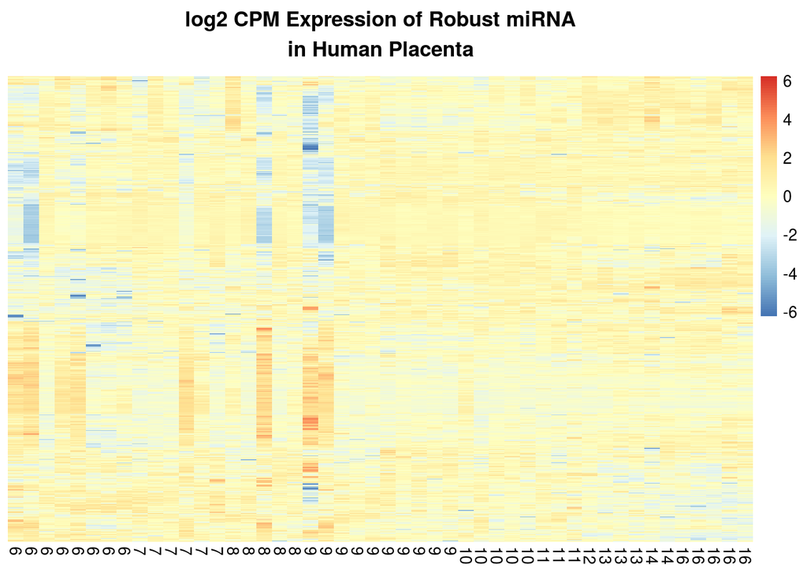

```r
library(pheatmap)

# df with sample name and weeks only
weeks <- samples[, c("samplename", "gestation")]

# df of lcpm expression by weeks' gestation
expressionWithWeek <- as.data.frame(t(lcpm)) %>%
  tibble::rownames_to_column() %>%
  rename(c('rowname' = 'samplename')) %>%
  left_join(., weeks, by = 'samplename') %>%
  select(samplename, gestation, everything()) %>%
  select(., -samplename) %>%
  arrange(gestation) %>%
  t() %>%
  set_colnames(. [1,]) %>%
  as.data.frame()
expressionWithWeek <- expressionWithWeek[-1, ]

# create heatmap of all robust miRNA using lcpm expression
pheatmap(expressionWithWeek,
         cluster_cols = FALSE,
         cluster_rows = TRUE,
         legend = TRUE,
         scale = "row",
         main="log2 CPM Expression of Robust miRNA\nin Human Placenta",
         show_rownames = FALSE,
         treeheight_row = 0)
```

# Time switching miRs

## unique miRs by week counts filtered to exclude < 2 samples per week showing expression.

This code chunk is written to:  
- filter any sequencing noise from the initial placenta counts table  
- replace sample names with gestational age by week  
- remove any rows (miRs) with fewer than 2 counts in a single week (ie where a miR is expressed in < 2 samples in a week it is considered not to be expressed in that week)  
- aggregate remaining counts into weeks  
- produce heat maps of binary expression vs no expression  
nb: this analysis uses the countsPlacenta object which has been filtered for sequencing noise (raw counts < 5 -> 0). The counts have not been filtered for low expression, and have not been normalised. I consider this acceptable as the filter for minimum representation (2 samples in any week) has been applied, and the counts are only considered as a binary (on/off) varible such that the actual expression values are not relevant.

```r
library(tidyverse)
library(reshape2)
```

```r
library(pheatmap)

# set ggplot2 theme
theme_set(theme_bw())

# exclude any individual count less than 5
#countsPlacenta[countsPlacenta < 5] <- 0
sampleWeek <- samples[, c(1, 3)] # select on the samplename and gestation (week) columns from the samples df

# create a new transformed df of un-normalised counts with samplename as the first column
countsByWeek <- t(countsPlacenta) %>%
  as.data.frame() %>%
  tibble::rownames_to_column() %>%
  plyr::rename(c('rowname' = 'samplename'))

countsByWeek <- left_join(sampleWeek, countsByWeek, by = "samplename") # left join the samples and counts data

countsByWeek <- dplyr::arrange(countsByWeek, gestation) # arrange ascending by gestation week

# counts data by week & filter
filtWeek06 <- subset(countsByWeek, gestation == 6) %>%
  t()
filtWeek06 <- filtWeek06[ rowSums(filtWeek06 > 0) >= 2, ]  %>%
  data.frame()
filtWeek06$week06 <- rep(1, nrow(filtWeek06)) # make new column filled with 1s
filtWeek06 <- filtWeek06[c(-1, -2), ] %>%
  subset(., select = week06) %>%
  tibble::rownames_to_column() %>%
  plyr::rename(c('rowname' = 'miRNA')) %>%
  as.data.frame()

filtWeek07 <- subset(countsByWeek, gestation == 7) %>%
  t()
filtWeek07 <- filtWeek07[ rowSums(filtWeek07 > 0) >= 2, ]  %>%
  data.frame()
filtWeek07$week07 <- rep(1, nrow(filtWeek07)) # make new column
filtWeek07 <- filtWeek07[c(-1, -2), ] %>%
  subset(., select = week07)  %>%
  tibble::rownames_to_column() %>%
  plyr::rename(c('rowname' = 'miRNA')) %>%
  as.data.frame()

filtWeek08 <- subset(countsByWeek, gestation == 8) %>%
  t()
filtWeek08 <- filtWeek08[ rowSums(filtWeek08 > 0) >= 2, ]   %>%
  data.frame()
filtWeek08$week08 <- rep(1, nrow(filtWeek08)) # make new column
filtWeek08 <- filtWeek08[c(-1, -2), ] %>%
  subset(., select = week08)  %>%
  tibble::rownames_to_column() %>%
  plyr::rename(c('rowname' = 'miRNA')) %>%
  as.data.frame()

filtWeek09 <- subset(countsByWeek, gestation == 9) %>%
  t()
filtWeek09 <- filtWeek09[ rowSums(filtWeek09 > 0) >= 2, ]  %>%
  data.frame()
filtWeek09$week09 <- rep(1, nrow(filtWeek09)) # make new column
filtWeek09 <- filtWeek09[c(-1, -2), ] %>%
  subset(., select = week09)  %>%
  tibble::rownames_to_column() %>%
  plyr::rename(c('rowname' = 'miRNA')) %>%
  as.data.frame()

filtWeek10 <- subset(countsByWeek, gestation == 10) %>%
  t()
filtWeek10 <- filtWeek10[ rowSums(filtWeek10 > 0) >= 2, ]   %>%
  data.frame()
filtWeek10$week10 <- rep(1, nrow(filtWeek10)) # make new column
filtWeek10 <- filtWeek10[c(-1, -2), ] %>%
  subset(., select = week10)  %>%
  tibble::rownames_to_column() %>%
  plyr::rename(c('rowname' = 'miRNA')) %>%
  as.data.frame()

filtWeek11 <- subset(countsByWeek, gestation == 11) %>%
  t()
filtWeek11 <- filtWeek11[ rowSums(filtWeek11 > 0) >= 2, ]  %>%
  data.frame()
filtWeek11$week11 <- rep(1, nrow(filtWeek11)) # make new column
filtWeek11 <- filtWeek11[c(-1, -2), ] %>%
  subset(., select = week11)  %>%
  tibble::rownames_to_column() %>%
  plyr::rename(c('rowname' = 'miRNA')) %>%
  as.data.frame()

# Week 12 excluded (for now) from further analysis as it only has one sample #
# filtWeek12 <- subset(countsByWeek, gestation == 12) %>%
#  t()
# filtWeek12 <- filtWeek12[ rowSums(filtWeek12 > 0) >= 2, ]  %>%
#   data.frame()
# filtWeek12$week12 <- rep(1, nrow(filtWeek12)) # make new column
# filtWeek12 <- filtWeek12[c(-1, -2), ] %>%
#   subset(., select = week12)  %>%
#   tibble::rownames_to_column() %>%
#   plyr::rename(c('rowname' = 'miRNA')) %>%
#   as.data.frame()

filtWeek13 <- subset(countsByWeek, gestation == 13) %>%
  t()
filtWeek13 <- filtWeek13[ rowSums(filtWeek13 > 0) >= 2, ]  %>%
  data.frame()
filtWeek13$week13 <- rep(1, nrow(filtWeek13)) # make new column
filtWeek13 <- filtWeek13[c(-1, -2), ] %>%
  subset(., select = week13)  %>%
  tibble::rownames_to_column() %>%
  plyr::rename(c('rowname' = 'miRNA')) %>%
  as.data.frame()

filtWeek14 <- subset(countsByWeek, gestation == 14) %>%
  t()
filtWeek14 <- filtWeek14[ rowSums(filtWeek14 > 0) >= 2, ]  %>%
  data.frame()
filtWeek14$week14 <- rep(1, nrow(filtWeek14)) # make new column
filtWeek14 <- filtWeek14[c(-1, -2), ] %>%
  subset(., select = week14)  %>%
  tibble::rownames_to_column() %>%
  plyr::rename(c('rowname' = 'miRNA')) %>%
  as.data.frame()

filtWeek16 <- subset(countsByWeek, gestation == 16) %>%
  t()
filtWeek16 <- filtWeek16[ rowSums(filtWeek16 > 0) >= 2, ]  %>%
  data.frame()
filtWeek16$week16 <- rep(1, nrow(filtWeek16)) # make new column
filtWeek16 <- filtWeek16[c(-1, -2), ] %>%
  subset(., select = week16)  %>%
  tibble::rownames_to_column() %>%
  plyr::rename(c('rowname' = 'miRNA')) %>%
  as.data.frame()

countsByWeek <- full_join(filtWeek06, filtWeek07, by  = "miRNA") %>%
  as.data.frame() %>%
  full_join(., filtWeek08, by='miRNA') %>%
  as.data.frame() %>%
  full_join(., filtWeek09, by='miRNA') %>%
  as.data.frame() %>%
  full_join(., filtWeek10, by='miRNA') %>%
  as.data.frame() %>%
  full_join(., filtWeek11, by='miRNA') %>%
  as.data.frame() %>%
  full_join(., filtWeek13, by='miRNA') %>%
  as.data.frame() %>%
  full_join(., filtWeek14, by='miRNA') %>%
  as.data.frame() %>%
  full_join(., filtWeek16, by='miRNA') %>%
  plyr::rename(c('miRNA' = 'rowname')) %>%
  as.data.frame()

countsByWeek[is.na(countsByWeek)] <- 0 # convert any NAs to zeros

# Plot and save multiple heat maps for binary expression (all filtered miRNAs)

# for(i in 1:18) {
#   counts_melt <- melt(countsByWeek[((i*60)-59):(i*60),])
#
# p <- ggplot(counts_melt, aes(variable, rowname)) +
#   geom_tile(aes(fill = as.factor(value)), colour = "white") +
#   scale_fill_manual(values = c("darksalmon", "forestgreen")) +
#   labs(x = "", y = "") +
#   ggtitle("miRNA Expression Profile\nin Human Placenta") +
#   theme(plot.title = element_text(hjust = 0.5)) +
#   theme(axis.text.x = element_text(angle = 90, hjust = 1, size = 4)) +
#   theme(legend.position = "none") +
#   theme(axis.title.y=element_blank(),
#         axis.text.y = element_text((counts_melt$rowname), size = 4)) +
#   coord_fixed(ratio=1)
#
# png(paste("plot_", i, ".png", sep = ""), width=600, height=500, res=120)
#   print(p)
#   dev.off()
# }
```

## Single week expression after filtering for >= 2 expression in given week

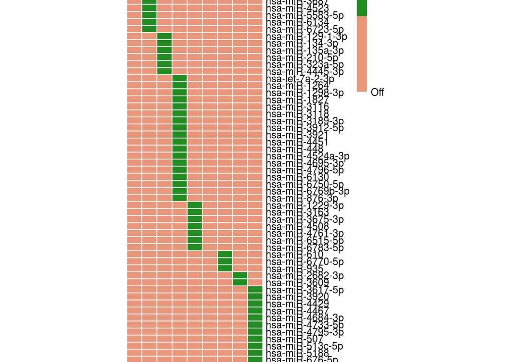

```r
# miRs with expression in one week only
w6 <- subset(countsByWeek, countsByWeek$week06 == 1 & (rowSums(countsByWeek[, 3:10]) == 0))
w7 <- subset(countsByWeek, countsByWeek$week07 == 1 & (rowSums(countsByWeek[, c(2, 4:10)]) == 0))
w8 <- subset(countsByWeek, countsByWeek$week08 == 1 & (rowSums(countsByWeek[, c(2:3, 5:10)]) == 0))
w9 <- subset(countsByWeek, countsByWeek$week09 == 1 & (rowSums(countsByWeek[, c(2:4, 6:10)]) == 0))
w10 <- subset(countsByWeek, countsByWeek$week10 == 1 & (rowSums(countsByWeek[, c(2:5, 7:10)]) == 0))
w11 <- subset(countsByWeek, countsByWeek$week11 == 1 & (rowSums(countsByWeek[, c(2:6, 8:10)]) == 0))
w13 <- subset(countsByWeek, countsByWeek$week13 == 1 & (rowSums(countsByWeek[, c(2:7, 9:10)]) == 0))
w14 <- subset(countsByWeek, countsByWeek$week14 == 1 & (rowSums(countsByWeek[, c(2:8, 10)]) == 0))
w16 <- subset(countsByWeek, countsByWeek$week16 == 1 & (rowSums(countsByWeek[, 2:9]) == 0))

singleWeekExpression <- bind_rows(w6, w7, w8, w9, w10, w11, w13, w14, w16) %>%
  tibble::column_to_rownames()

# only works before the cluster steps
pheatmap(as.matrix(singleWeekExpression),
         cluster_cols = FALSE,
         cluster_rows = FALSE,
         cellwidth = 15,
         cellheight = 7,
         legend_breaks = c(1, 0),
         legend_labels = c("On", "Off"),
         color = c("darksalmon", "forestgreen"),
         border_color = "white",
         labels_col = c("Week 6", "Week 7", "Week 8", "Week 9", "Week 10", "Week 11", "Week 12", "Week 13", "Week 14", "Week 16"),
         main="Binary Expression in Placenta")
```

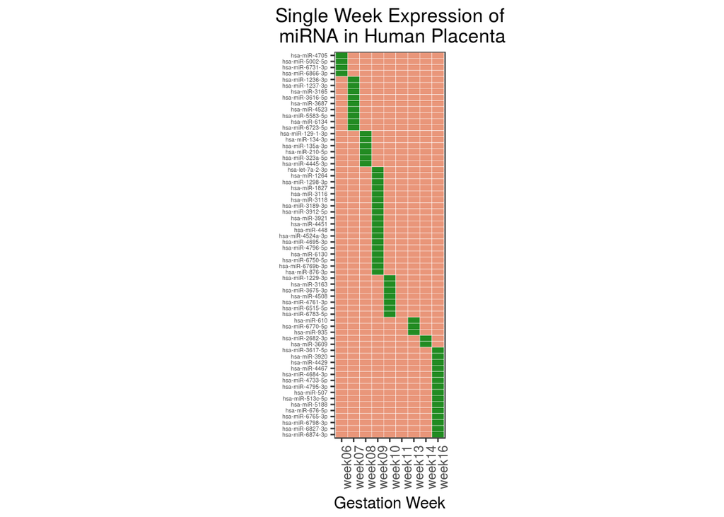

```r
# cluster to obtain order for heatmap (default distance method = euclidean)
clust <- hclust(dist(singleWeekExpression))

# order oxygenMediatedExpression by cluster order
singleWeekExpression <- singleWeekExpression[match(clust$labels, rownames(singleWeekExpression)), ] %>%
  tibble::rownames_to_column()

# Heatmap of miRNA in placenta with expression >=2 weeks before or after the 10 week line and nothing on the other side.
singleCounts_melt <- melt(singleWeekExpression, id = "rowname") %>%
  rename(c('rowname' = 'miRNA'))

ggplot(singleCounts_melt, aes(variable, miRNA)) +
  geom_tile(aes(fill = as.factor(value)), colour = "white") +
  scale_fill_manual(values = c("darksalmon", "forestgreen")) +
  scale_y_discrete(name="", limits = rev(clust$labels)) +
  labs(x = "Gestation Week", y = "") +
  ggtitle("Single Week Expression of\n miRNA in Human Placenta") +
  theme(plot.title = element_text(hjust = 0.5)) +
  theme(axis.text.x = element_text(angle = 90, hjust = 1)) +
  theme(legend.position = "none") +
  theme(axis.title.y=element_blank(),
      axis.text.y = element_text((singleCounts_melt$rowname), size = 4)) +
  coord_fixed(ratio=.5)
```

## Hypoxic versus oxygentated expression after filtering for >= 2 expression in given week

There is a change in placental function around the 10 weeks’ gestation mark when the placenta infiltrates the maternal blood space and begins to extract oxygen and nutrients from the mother as well as discard waste.  
Here I’m looking for miRs which are specific to either to pre or post infiltration stage. To identify these miRs I’ve used a filter whereby miRs with expression in at least 2 weeks prior to the week 10 cut off (ie columns 2:5) but nothing after are subset. Then miRs with expression in at least 2 samples post the week 10 cut off (ie columns 7:10) but nothing before the cut off are subset. The two subsetted df are then concatonated to produce a df of only miRs which fit the two filter criteria.

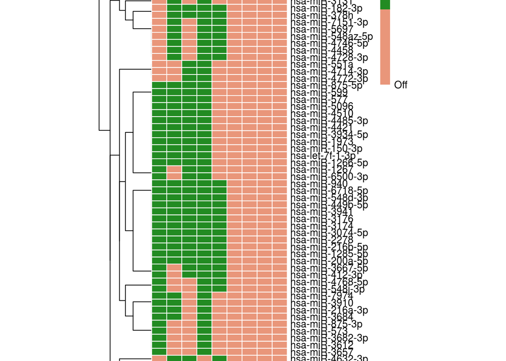

```r
left <- subset(countsByWeek, (rowSums(countsByWeek[, 2:5]) > 1 & (rowSums(countsByWeek[, 7:10]) < 1)))

right <- subset(countsByWeek, (rowSums(countsByWeek[, 2:5]) < 1 & (rowSums(countsByWeek[, 7:10]) > 1)))

oxygenMediatedExpression <- bind_rows(left, right) %>%
  tibble::column_to_rownames()

# only works before the cluster steps
pheatmap(as.matrix(oxygenMediatedExpression),
         cluster_cols = FALSE,
         cluster_rows = TRUE,
         cellwidth = 15,
         cellheight = 7,
         legend_breaks = c(1, 0),
         legend_labels = c("On", "Off"),
         color = c("darksalmon", "forestgreen"),
         border_color = "white",
         labels_col = c("Week 6", "Week 7", "Week 8", "Week 9", "Week 10", "Week 11", "Week 12", "Week 13", "Week 14", "Week 16"),
         main="Binary Expression in Placenta")
```

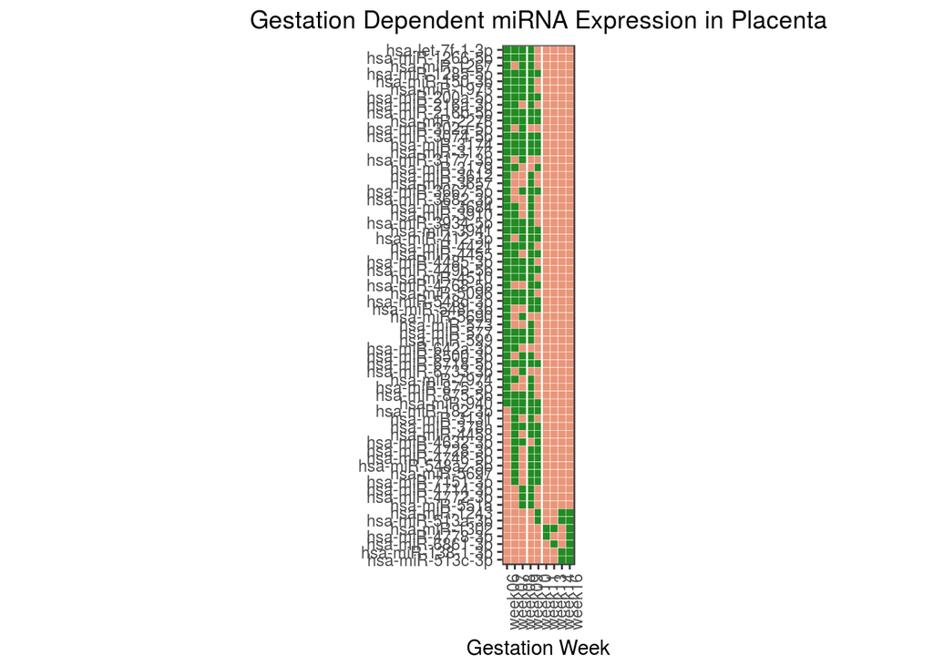

```r
# cluster to obtain order for heatmap (default distance method = euclidean)
clust <- hclust(dist(oxygenMediatedExpression))

# order oxygenMediatedExpression by cluster order
oxygenMediatedExpression <- oxygenMediatedExpression[match(clust$labels, rownames(oxygenMediatedExpression)), ] %>%
  tibble::rownames_to_column()

# Heatmap of miRNA in placenta with expression >=2 weeks before or after the 10 week line and nothing on the other side.
hypoxicCounts_melt <- melt(oxygenMediatedExpression, id = "rowname") %>%
  rename(c('rowname' = 'miRNA'))

ggplot(hypoxicCounts_melt, aes(variable, miRNA)) +
  geom_tile(aes(fill = as.factor(value)), colour = "white") +
  scale_fill_manual(values = c("darksalmon", "forestgreen")) +
  scale_y_discrete(name="", limits = rev(clust$labels)) +
  labs(x = "Gestation Week", y = "") +
  ggtitle("Gestation Dependent miRNA Expression in Placenta") +
  theme(plot.title = element_text(hjust = 0.5)) +
  theme(axis.text.x = element_text(angle = 90, hjust = 1)) +
  theme(legend.position = "none") +
  theme(axis.title.y=element_blank(),
      axis.text.y = element_text(hypoxicCounts_melt$rowname)) +
  geom_vline(xintercept=3.55, colour = "white") +
  geom_vline(xintercept=5.45, colour = "white") +
  coord_fixed(ratio=1)
```

## unique miRs by fetal sex (counts filtered to exclude miRs w/ < 2 samples per week showing expression)

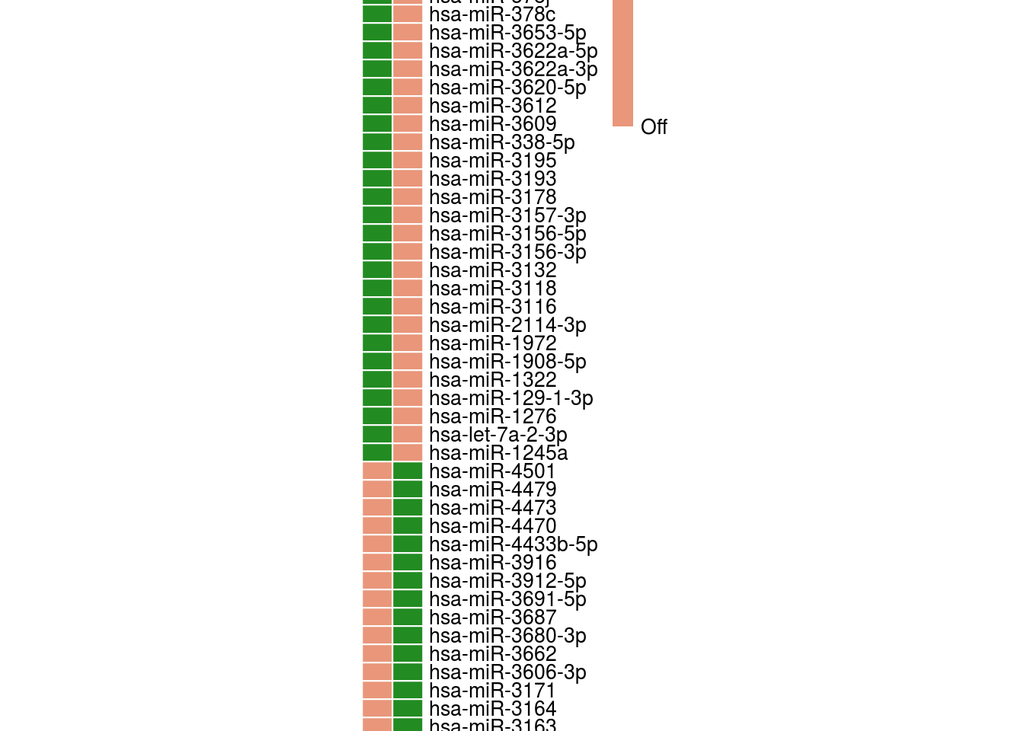

```r
sampleSex <- samples[, c(1, 9)] # select on the samplename and gestation (week) columns from the samples df

# new df of un-normalised counts
countsBySex <- t(countsPlacenta) %>%
  as.data.frame() %>%
  tibble::rownames_to_column() # create a new transformed df of un-normalised counts with samplename as the first column

countsBySex <- left_join(sampleSex, countsBySex, by = c("samplename" = "rowname")) # left join the samples and counts data
countsBySex <- countsBySex[, -1] # remove unwanted samplename column


countsBySex <- aggregate(countsBySex, by = list(countsBySex$Sex), FUN = mean)[, -2] %>%
  rename(c('Group.1' = 'rowname')) %>%
  tibble::column_to_rownames() # aggregate the counts df such that each week now only has a single observation per miR

countsBySex <- t(countsBySex) # new counts df all finished with weeks as column headers - counts are means within weeks

# Heat Map of binary expression by fetal sex - all non-zero counts converted to 1.
countsBySex[which(countsBySex != 0)] <- 1

# new df all miRs for each fetal sex
Female <- countsBySex[, "Female"] %>%
  as.data.frame() %>%
  tibble::rownames_to_column() %>%
  set_colnames(c("miRNA", "Female"))
Female <- Female[!(Female$Female==0),]

Male <- countsBySex[, "Male"]  %>%
  as.data.frame() %>%
  tibble::rownames_to_column() %>%
  set_colnames(c("miRNA", "Male"))
Male <- Male[!(Male$Male==0),]

# miRNAs with ubiquitous expression (expressed in both male and female)
ubiquitous <- countsBySex[ rowSums(countsBySex)==2, ] %>%
  as.data.frame()

# miRNAs with sex specific expression (expressed in either male or female, but not both)
sexSpecific <- countsBySex[ rowSums(countsBySex)==1, ] %>%
  as.data.frame()

pheatmap(sexSpecific[1:60,],
         cluster_cols = FALSE,
         cluster_rows = TRUE,
         cellwidth = 15,
         cellheight = 9,
         legend_breaks = c(1, 0),
         legend_labels = c("On", "Off"),
         color = c("darksalmon", "forestgreen"),
         border_color = "white",
         treeheight_row = 0,
         labels_col = c("Female", "Male"),
         main="Binary Expression in\n Placenta by Fetal Sex")
```

```r
# simple df of miRNA expressed only in male samples
maleOnly <- sexSpecific[, "Male", drop=FALSE] %>%
  as.data.frame() %>%
  set_colnames("Male")
# remove miRNAs with zero counts in all samples
maleOnly <- maleOnly[ rowSums(maleOnly)!=0, , drop = FALSE] %>%
  as.data.frame()

# simple df of miRNA expressed only in female samples
femaleOnly <- sexSpecific[, "Female", drop=FALSE] %>%
  as.data.frame() %>%
  set_colnames("Female")
# remove miRNAs with zero counts in all samples
femaleOnly <-femaleOnly[ rowSums(femaleOnly)!=0, , drop = FALSE] %>%
  as.data.frame()

mirbase_db <- readRDS("~/Bcbioplasma/mirbase_db.rds")
```